# DASC5420-Project

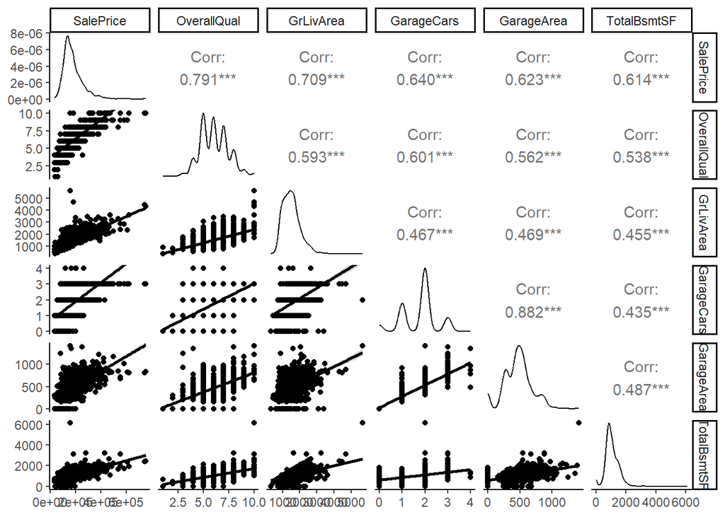

```r
# view scatterplot matrix
ggpairs(data[, c("SalePrice", "OverallQual", "GrLivArea", "GarageCars", "GarageArea", "TotalBsmtSF")], lower = list(continuous = "smooth"), diag = list(continuous = "density"))
```

This scatterplot matrix shows the distribution, relationships and correlation between target variable, housing sale prices and several predictors, as well as between predictors.

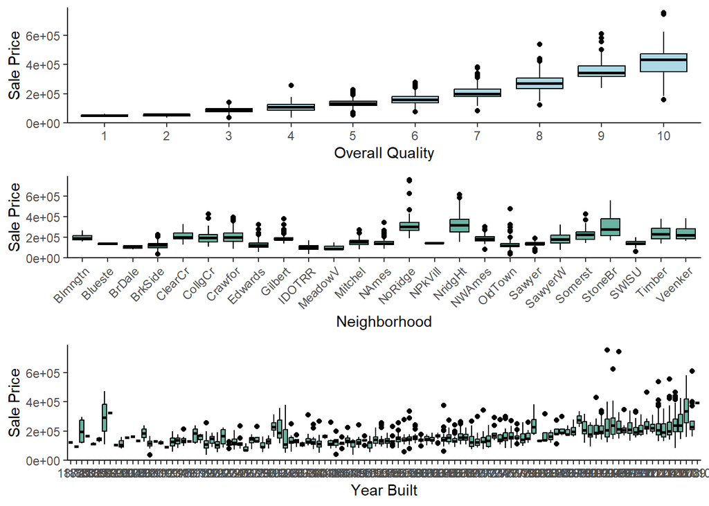

```r
# View boxplots of SalePrice by various categorical variables
p1 <- ggplot(data, aes(x = as.factor(OverallQual), y = SalePrice)) +
  geom_boxplot(fill = "lightblue", color = "black") +
  labs(x = "Overall Quality", y = "Sale Price")

p2 <- ggplot(data, aes(x = as.factor(Neighborhood), y = SalePrice)) +
  geom_boxplot(fill = "#69b3a2", color = "black") +
  labs(x = "Neighborhood", y = "Sale Price") +
  theme(axis.text.x = element_text(angle = 45, hjust = 1))

p3 <- ggplot(data, aes(x = as.factor(YearBuilt), y = SalePrice)) +
  geom_boxplot(fill = "#69b3a2", color = "black") +
  labs(x = "Year Built", y = "Sale Price")

grid.arrange(p1, p2, p3, ncol = 1)
```

The boxplots of the sale price by overall quality, neighborhood, and year built showed some significant differences in the median sale prices across these variables.

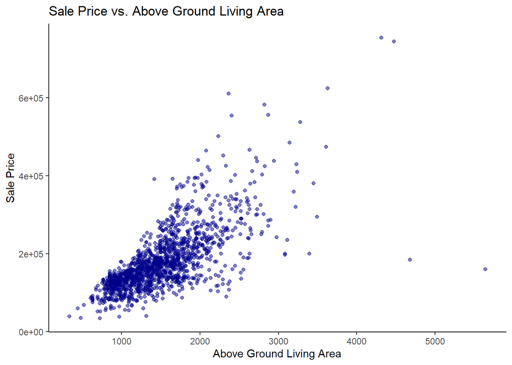

```r
# plot scatterplot of SalePrice and GrLivArea
ggplot(data, aes(x = GrLivArea, y = SalePrice)) +
  geom_point(color = "darkblue", alpha = 0.5) +
  labs(title = "Sale Price vs. Above Ground Living Area", x = "Above Ground Living Area", y = "Sale Price")
```

The scatterplot of sale price and above ground living areas shows a positive correlation between these variables.

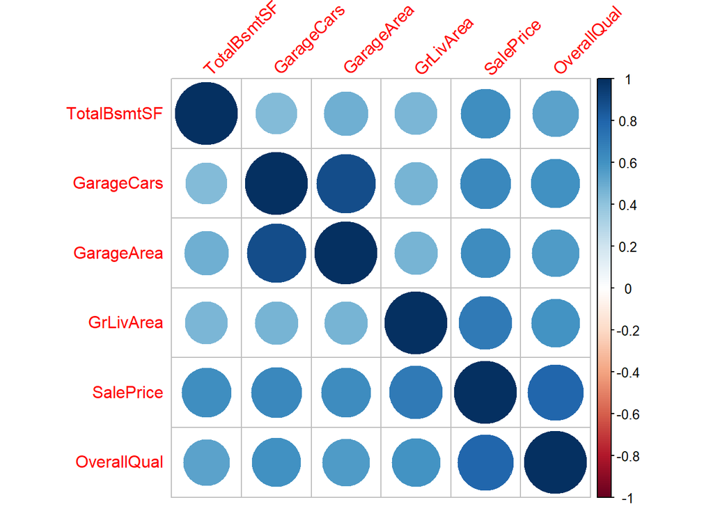

```r
# plot correlation matrix
corrplot(cor(data[, c("SalePrice", "OverallQual", "GrLivArea", "GarageCars", "GarageArea", "TotalBsmtSF")]),method = "circle", order = "hclust", tl.srt = 45)
```

Correlation matrix plot show how strong relationship between housing sale price and several independent variables.

## Data Transformation

```r
colSums(is.na(data))
```

```
##            Id    MSSubClass      MSZoning   LotFrontage       LotArea
##             0             0             0           259             0
##        Street         Alley      LotShape   LandContour     Utilities
##             0          1369             0             0             0
##     LotConfig     LandSlope  Neighborhood    Condition1    Condition2
##             0             0             0             0             0
##      BldgType    HouseStyle   OverallQual   OverallCond     YearBuilt
##             0             0             0             0             0
##  YearRemodAdd     RoofStyle      RoofMatl   Exterior1st   Exterior2nd
##             0             0             0             0             0
##    MasVnrType    MasVnrArea     ExterQual     ExterCond    Foundation
##             8             8             0             0             0
##      BsmtQual      BsmtCond  BsmtExposure  BsmtFinType1    BsmtFinSF1
##            37            37            38            37             0
##  BsmtFinType2    BsmtFinSF2     BsmtUnfSF   TotalBsmtSF       Heating
##            38             0             0             0             0
##     HeatingQC    CentralAir    Electrical     X1stFlrSF     X2ndFlrSF
##             0             0             1             0             0
##  LowQualFinSF     GrLivArea  BsmtFullBath  BsmtHalfBath      FullBath
##             0             0             0             0             0
##      HalfBath  BedroomAbvGr  KitchenAbvGr   KitchenQual  TotRmsAbvGrd
##             0             0             0             0             0
##    Functional    Fireplaces   FireplaceQu    GarageType   GarageYrBlt
##             0             0           690            81            81
##  GarageFinish    GarageCars    GarageArea    GarageQual    GarageCond
##            81             0             0            81            81
##    PavedDrive    WoodDeckSF   OpenPorchSF EnclosedPorch    X3SsnPorch
##             0             0             0             0             0
##   ScreenPorch      PoolArea        PoolQC         Fence   MiscFeature
##             0             0          1453          1179          1406
##       MiscVal        MoSold        YrSold      SaleType SaleCondition
##             0             0             0             0             0
##     SalePrice
##             0
```

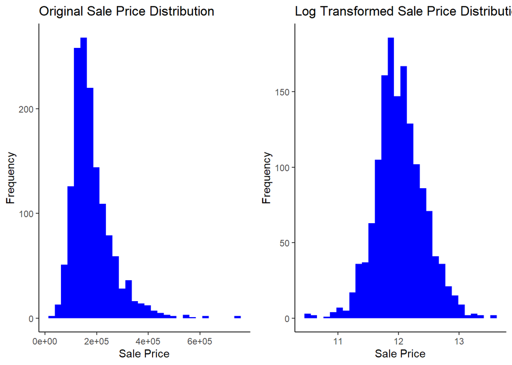

```r
# copy original data for data transformation
data.clean <- data

# transform response SalePrice into log scale
data.clean$SalePrice <- log(data.clean$SalePrice)

# original SalePrice histogram
p4 <- ggplot(data, aes(SalePrice))+
  geom_histogram(fill= "blue", bins = 30)+
  labs(title = "Original Sale Price Distribution", x = "Sale Price", y = "Frequency")+
  theme_classic()

# transformed SalePrice histogram
p5 <- ggplot(data.clean, aes(SalePrice))+
  geom_histogram(fill= "blue", bins = 30)+
  labs(title = "Log Transformed Sale Price Distribution", x = "Sale Price", y = "Frequency")+
  theme_classic()

grid.arrange(p4, p5, ncol = 2)
```

Comparison of sale price distribution before and after log transformation. Log transformed of sale price has a normal distribution. This transformation help to improve model accuracy of model in predicting sale price.

```r
# remove unnecessary variables and predictors that has huge number of missing data
data.clean <- data.clean[, !(names(data.clean) %in% c('Id', 'Utilities', 'Street','Alley', 'FireplaceQu',
                                                      'PoolQC', 'MiscFeature', 'MiscVal'))]
```

```r
# Change data types in numerical features that should be categorical
data.clean$MSSubClass <- as.character(data.clean$MSSubClass)
data.clean$YrSold <- as.character(data.clean$YrSold)
data.clean$MoSold <- as.character(data.clean$MoSold)
```

```r
# replace corrupted data
data.clean$Exterior1st <- ifelse(data.clean$Exterior1st == "Wd Sdng", "WdSdng", data.clean$Exterior1st)
data.clean$Exterior2nd <- ifelse(data.clean$Exterior2nd == "Wd Sdng", "WdSdng", data.clean$Exterior2nd)
data.clean$Exterior2nd <- ifelse(data.clean$Exterior2nd == "Wd Shng", "WdShng", data.clean$Exterior2nd)
data.clean$Exterior2nd <- ifelse(data.clean$Exterior2nd == "Brk Cmn", "BrkCmn", data.clean$Exterior2nd)
data.clean$MSZoning <- ifelse(data.clean$MSZoning == "C (all)", "C", data.clean$MSZoning)
```

```r
# get list of character and numeric columns
char.cols <- get.char.cols(data.clean)
num.cols <- get.numeric.cols(data.clean)
```

```r
# handle missing
data.clean$Electrical <- ifelse(is.na(data.clean$Electrical), "SBrkr", data.clean$Electrical)

# replace character predictors missing values with None
data.clean[char.cols] <- lapply(data.clean[char.cols], function(x) ifelse(is.na(x), "None", x))

# replace remaining numeric predictors missing values with 0
data.clean[num.cols] <- lapply(data.clean[num.cols], function(x) ifelse(is.na(x), 0, x))
```

```r
# generate new variable
data.clean$TotalSqrFeet = data.clean$BsmtFinSF1 + data.clean$BsmtFinSF2 + data.clean$X1stFlrSF + data.clean$X2ndFlrSF
```

```r
# encode categorical columns
char.cols <- get.char.cols(data.clean)
data.clean <- get_dummies(data.clean, cols = char.cols, prefix = T, prefix_sep = "_", drop_first = T, dummify_na = F)

# cleaned data for models
data.clean <- dplyr::select(data.clean, -char.cols)
```